# CS559_F21_midterm-solution

CS559 Fall 2021 Midterm

Due: in 90 minutes

The second part of the midterm contains the computations to solve machine learning problems. It is an open-notes exam and students can only use lecture notes and demonstration files provided from the class. Students are not allowed to use any other modules than $\color{red}{\textbf{Numpy, Pandas, and Matplot}}$.

Although there are no plotting questions, students are welcome to display plots to confirm their answers.

Students must submit the exam **90 minutes from the start**.

Good luck!

```python
import numpy as np
import pandas as pd
import matplotlib.pyplot as plt
```

## Question 1 [20 pts]

This question is a gradient descent problem and students are required to find a weight vector of the actual quadratic function of the provided data, `gradient_question.csv`. The dataset has two columns, x and y, where y is the true target variable.

### 1-1.

Write a short function called `my_gradient()` that optimizes the weight vector using the squared error function and returns the weight vector when the acceptance of error is below 0.05 and the learning rate $\eta$ is 0.001. [12 pts]

```python
def my_grad(X,Y):
    w1 = 0.0; w2=0.0; eta=0.001
    gradient_w1=0; gradient_w2=0
    for i in range(0,10000):
        y = w1*X**2+w2*X
        error = (Y-y)
        gradient_w1 = np.mean(-X**2*error)
        gradient_w2 = np.mean(-X*error)
        w1 = w1-eta*gradient_w1
        w2 = w2-eta*gradient_w2
        if np.mean(error**2)<=0.05:
            print(w1,w2,np.mean(error**2)/2)
            break
    return w1, w2
```

### 1-2.

Using the optimized weight vector, find the local maximum. [8 pts]

```python
### code starts here.
data = pd.read_csv('./gradient_question.csv')
w1, w2 = my_grad(data.x,data.y)
print(w1, w2)
```

```
-5.000370287541518 30.10987721267936
```

```python
dx=-w2/(w1*2)
print(dx,w1*dx**2+w2*(dx))
```

```
3.0107647515323492 45.32687849245106
```

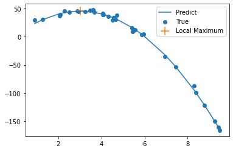

```python
data=data.sort_values('x')
plt.scatter(data.x,data.y,label='True')
plt.plot(data.x,w1*data.x**2+w2*data.x,label='Predict')
plt.scatter(dx,w1*dx**2+w2*(dx),label='Local Maximum',marker='+',s=200)
plt.legend()
plt.show()
```

## Question 2 [20 pts]

This question is a probability classification problem. Assuming that training a mixture of Gaussians model by maximum likelihood, students will find P(1|0.75) using data `Probability_Classification.csv`. In the dataset, there are two columns, **x** and **class**, where the **class** is the binary class.

### 2-1

Find the prior, expected value, and variance for each class. [12 pts]

```python
### code starts here
### code starts here
prob_clf = pd.read_csv('./Probability_Classification.csv')

### Prior Probability Computation:

Pr1=prob_clf[prob_clf['class']==1]
Pr0=prob_clf[prob_clf['class']==0]

Prior1, Prior0 = len(Pr1)/len(prob_clf),len(Pr0)/len(prob_clf)
print(Prior1, Prior0)

### Compute mean of each class:
mean1=np.mean(Pr1.x)
mean0=np.mean(Pr0.x)
print(meanP,meanM)
### Compute variance of each class:
var1=np.mean((Pr1.x-meanP)**2)
var0=np.mean((Pr0.x-meanM)**2)
print(varP,varM)
### Compute variance
variance=Prior1*var1+Prior0*var0
print(variance)
```

```
0.5625 0.4375
0.6093683605555555 0.41685643071428563
0.9656620380982928 1.1314040073498226
1.038174149645837
```

### 2-2

Find the probability P(1|0.75)? [8 pts]

```python
### code starts here
Pr1x=np.exp(-Prior1*(0.75-mean1)**2/variance)
Pr0x=np.exp(-Prior0*(0.75-mean0)**2/variance)
Pr=Prior1*Pr1x/(Prior1*(Pr1x+Pr0x))
print("Pr(0.75|1)=",Pr1x)
print("Pr(0.75|0)=",Pr0x)
print("Pr(1|0.75)=",Pr)
```

```
Pr(0.75|1)= 0.9893415610988024
Pr(0.75|0)= 0.9543065191061253
Pr(1|0.75)= 0.50901270202911
```

### 3-1

Using the weight vector $\vec{w}=[-5.653, 1.199, 0.822]$, build a Logisitc Regression Classifier, $\sigma(\vec{w}\cdot \vec{x})\ge0.5$, and classify each $\vec{x}=[x1,x2]^T$. Please do not copy and use the implemented logistic regression from Assignment 2. Determine which class $\vec{x}=[3,3]^T$ belongs to. [10 pts]

```python
### code starts here
### code starts here
data3 = pd.read_csv('./LR_SVM.csv')

w1=1.199
w2=0.822
w0=-5.653

y_pred_lr=1/(1+np.exp(-(w1*data3.x1+w2*data3.x2+w0)))
y_lr = []
for y_lr,y in zip(y_pred_lr,data3.y):
    if y_lr>=0.5:
        y_=1
        print(y_,y)
    else:
        y_=0
        print(y_,y)
```

```
1 1
1 1
0 -1
0 -1
1 1
0 -1
1 1
0 -1
0 -1
1 1
```

```python
y_pred_lr=1/(1+np.exp(-(w1*3+w2*3+w0)))
if y_pred_lr>=0.5:
    y_=1
    print("(3,3)",y_)
else:
    y_=0
    print("(3,3)",y_)
```

```
(3,3) 1
```

### 3-2

You are going to build a SVM classifier by following: a) Find the equation of the SVM hyperplane h(x) and classify each $\vec{x}$, b) calculate the distance of each point from the hyperplane and print the support vectors, and c) classify the point $\vec{x}=[3,3]^T$ using h(x) from a). [10 pts]

```python
### code starts here
w1 = np.sum(data3.a*data3.y*data3.x1)
w2 = np.sum(data3.a*data3.y*data3.x2)
data3_b = data3[data3['a']>0]
b=np.sum(data3_b.y-(w1*data3_b.x1+w2*data3_b.x2))/len(data3_b)
print("y(x)=",w1,"x1+",w2,"x2+",b)
```

```
y(x)= 0.846 x1+ 0.3852 x2+ -3.5009999999999994
```

```python
y_ = w1*data3.x1+w2*data3.x2+b
for y_i,y in zip(y_,data3.y):
    if y_i>0:
        y_svm=1
        print(y_svm,y)
    elif y_i<0:
        y_svm=-1
        print(y_svm,y)
    else:
        y_svm=0
```

```
1 1
1 1
-1 -1
-1 -1
1 1
-1 -1
1 1
-1 -1
-1 -1
1 1
```

```python
d=abs(w1*data3.x1+w2*data3.x2+b)/np.sqrt(w1**2+w2**2)
print("margin distance=",np.min(d))

w11=-w1/w2
w21=-b/w2
print("h(x)=",w11,'x +',w21)

y_int=2.9-w11*4.0-w21
print('two margins= h(x)+/-',y_int)
```

```
margin distance= 1.0758556031453892
h(x)= -2.196261682242991 x + 9.08878504672897
two margins= h(x)+/- 2.596261682242993
```

```python
x1, h, h1, h2 = [], [], [], []
for i in range(0,7):
    h_i=w11*i+w21
    x1.append(i)
    h.append(h_i)
    h_i=w11*i+w21-y_int
    h1.append(h_i)
    h_i=w11*i+w21+y_int
    h2.append(h_i)
```

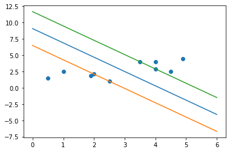

```python
plt.scatter(data3.x1,data3.x2)
plt.plot(x1,h)
plt.plot(x1,h1)
plt.plot(x1,h2)
plt.show()
```

```python
data3['d']=d
data3
```

|  | x1 | x2 | y | a | d |
| --- | --- | --- | --- | --- | --- |
| 0 | 4.0 | 2.9 | 1 | 0.414 | 1.075856 |
| 1 | 4.0 | 4.0 | 1 | 0.000 | 1.531681 |
| 2 | 1.0 | 2.5 | -1 | 0.000 | 1.820202 |
| 3 | 2.5 | 1.0 | -1 | 0.018 | 1.076630 |
| 4 | 4.9 | 4.5 | 1 | 0.000 | 2.557965 |
| 5 | 1.9 | 1.9 | -1 | 0.000 | 1.249743 |
| 6 | 3.5 | 4.0 | 1 | 0.018 | 1.076630 |
| 7 | 0.5 | 1.5 | -1 | 0.000 | 2.689639 |
| 8 | 2.0 | 2.1 | -1 | 0.414 | 1.075856 |
| 9 | 4.5 | 2.5 | 1 | 0.000 | 1.365152 |

```python
y_svm = w1*3+w2*3+b

if y_svm>0:
    y_svm=1
    print(y_svm)
elif y_svm<0:
    y_svm=-1
    print(y_svm)
else:
    y_svm=0
```

```
1
```